# India TB Pathways Analysis

Author

James Matosse

# Introduction

The India TB Pathways dataset is based on a study conducted in Vellore district, Tamil Nadu, India. It examines the pre-diagnostic costs and health-seeking behavior of 880 new adult pulmonary tuberculosis patients registered at Primary Health Centres (PHCs).

## The data tabulated

id

Sex

Age

Education

Employment

Alcohol

Smoking

WtinKgs

HtinCms

bmi

Diabetes

Form of TB

Chext Xray

first visit location

first visit cost

second visit location

second visit cost

third visit location

third visit cost

Health sys delay (in days)

Treatment initiation delay (in days)

[figure not shown]

## The Tamil Nadu map

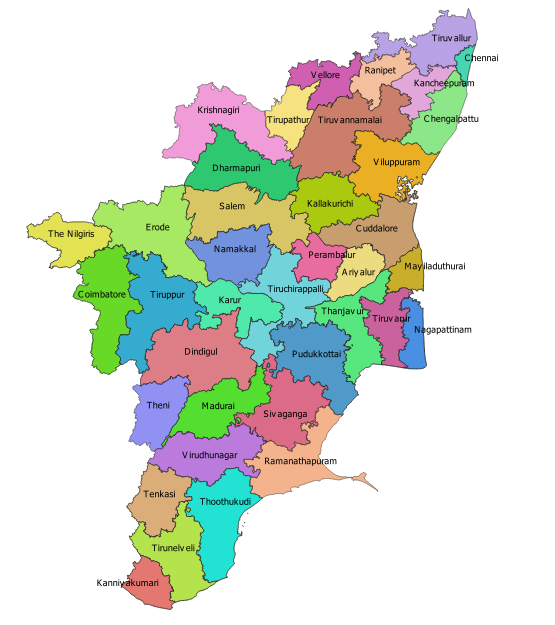

# Data visualised

[interactive chart not shown]

## Insights from the Box plots

The Graduate & Above group has the smallest range of delays from 2 to 4 days with a median at 3 days. This group receives their treatment the quickest, which shows that maybe they are more aware of their health and/or that the society/clinics treats the elderly and respected persons first before other groups. The missing group has the lowest median of 2.5 day, but since this is the group that did not indicate their education level, it can be ignored. No Education group has the highest delays with the upper fence at 25 days and outliers reaching maximum at 65 days. The Middle group has two extreme outliers at 98 and 110 days delay while the median is at 6 days.

# Inline Code challenge

Most of the patients answered **No** for smoking and the average bmi is **17.5** across all patients with the lowest bmi at **11** and maximum at **37**.